# Exercise 9.4

Kári Hlynsson

March 2024

Generate a simulated two-class data set with 100 observations and two features in which there is a visible but non-linear separation between the two classes. Show that in this setting, a support vector machine with a polynomial kernel (with degree greater than 1) or a radial kernel will outperform a support vector classifier on the training data. Which technique performs best on the test data? Make plots and report training and test error rates in order to back up your assertions.

The below code shows the data generation process. We start by generating 100 $x$-values where $x_i \sim \mathcal N(3.5, 1.75^2)$ and generate an $y$-coordinate using $y_i \sim \mathcal N(x_i^2 + 2x_i + 4, \epsilon_i)$ where $\epsilon_i \sim \mathcal N(0, 20^2)$. We classify the $y$-values into two classes, `blue` and `orange`, using the function
$$\chi_y(x) = 0.35 e^x$$
such that $c_i =$ `blue` if $y_i > \chi_y(x_i)$, and `orange` otherwise, where $c_i$ denoted the class label of the $i$th observation. The data points along with the classification boundary are shown in the figure below.

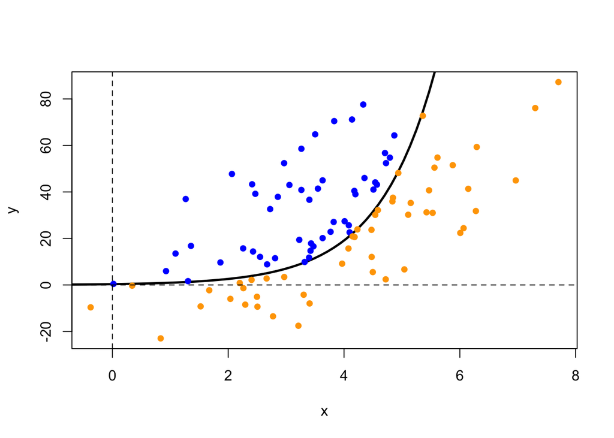

```r
set.seed(1)

p <- function(x) 0.35 * exp(x)
x <- rnorm(100, mean = 3.5, sd = 1.75)
y <- x^2 + 2 * x + 4 + rnorm(100, mean = 0, sd = 20)
k <- c()

for (i in 1:100) {
  k[i] <- ifelse(y[i] > p(x[i]), "blue", "orange")
}

plot(function(x) 0.35 * exp(x), from = -3, to = 8,
     xlim = range(x), ylim = range(y), lwd = 2.5,
     ylab = "y")
points(x, y, col = k, pch = 20, cex = 1.25)
abline(h = 0, lty = 2)
abline(v = 0, lty = 2)
```

```r
# train / test split
n_train <- 75
df <- data.frame(x = x, y = y, k = as.factor(k))
tr <- sample(1:100, n_train)
ts <- setdiff(1:100, tr)

train <- df[tr, ]
test <- df[ts, ]
```

Now let us try to classify these data using support vector classifiers and support vector machines and compare the two methods.

## SVC

```r
library(e1071)
library(caret)
library(scales)

svcfit <- svm(k ~ y + x, data = train, cost = 10, kernel = "linear")
svcfit_pred <- predict(svcfit, test)

svcfit_conf <- confusionMatrix(svcfit_pred, test$k)
svcfit_conf
```

```
## Confusion Matrix and Statistics
##
##           Reference
## Prediction blue orange
##     blue     12      4
##     orange    1      8
##
##                Accuracy : 0.8
##                  95% CI : (0.593, 0.9317)
##     No Information Rate : 0.52
##     P-Value [Acc > NIR] : 0.003724
##
##                   Kappa : 0.5955
##
##  Mcnemar's Test P-Value : 0.371093
##
##             Sensitivity : 0.9231
##             Specificity : 0.6667
##          Pos Pred Value : 0.7500
##          Neg Pred Value : 0.8889
##              Prevalence : 0.5200
##          Detection Rate : 0.4800
##    Detection Prevalence : 0.6400
##       Balanced Accuracy : 0.7949
##
##        'Positive' Class : blue
##
```

The accuracy with an out-of-the-box SVC is 0.8 – mediocre. Visualise the decision boundary:

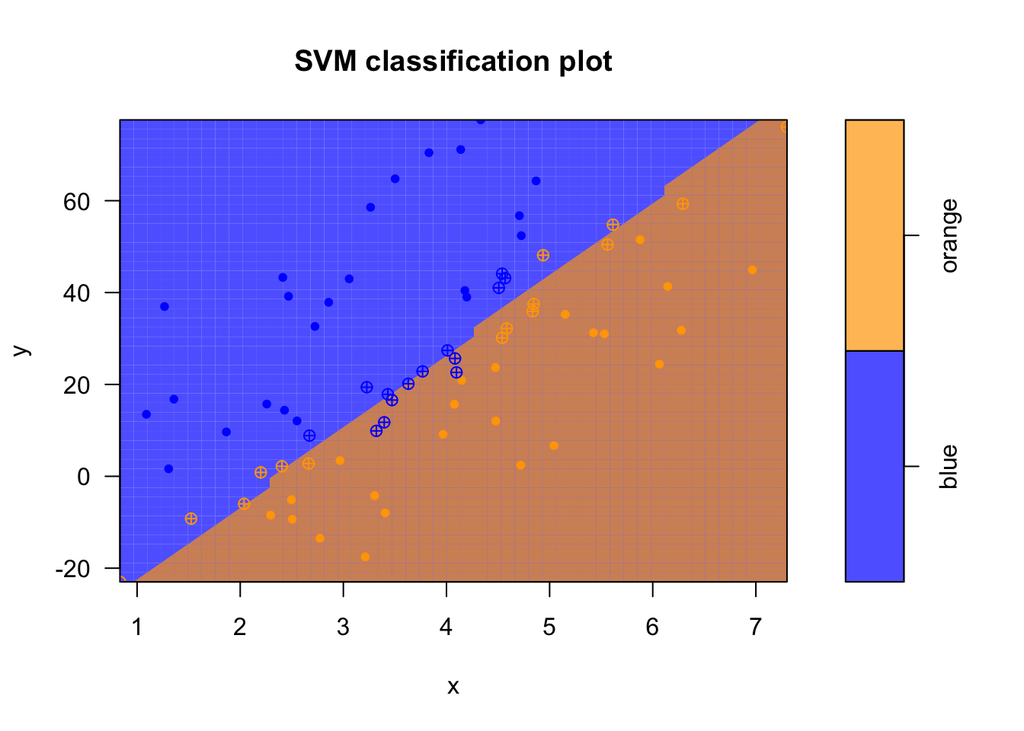

```r
plot(
  svcfit,
  train,
  symbolPalette = c("blue", "orange"),
  svSymbol = 10,
  dataSymbol = 20,
  color.palette = function(x) c(alpha("blue", 0.7), alpha("orange", 0.7))
)
```

CV over cost parameter to obtain more accurate model:

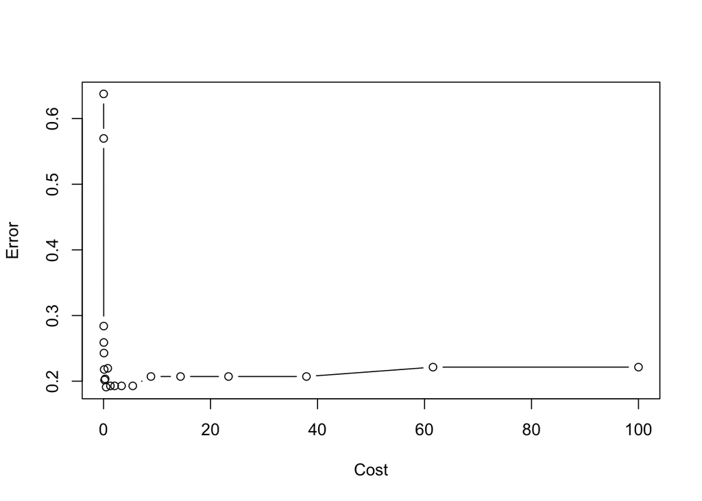

```r
svcfit_tuned <- tune(
  svm,
  k ~ y + x,
  data = train,
  kernel = "linear",
  ranges = list(
    cost = 10^seq(-2, 2, length.out = 20)
  )
)

tune_perf <- svcfit_tuned$performances

plot(tune_perf$cost, tune_perf$error, type = "b",
     xlab = "Cost", ylab = "Error")
```

The best value of cost is

```r
svcfit_tuned$best.parameters
```

```
##       cost
## 9 0.483293
```

Recover the best model:

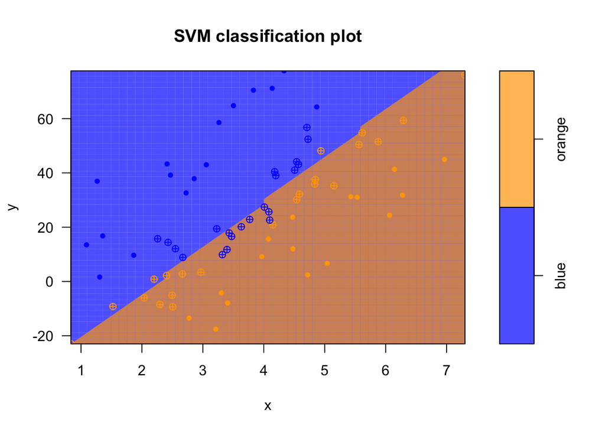

```r
svcfit_opt <- svcfit_tuned$best.model
svcfit_opt_pred <- predict(svcfit_opt, test)

plot(
  svcfit_opt,
  train,
  symbolPalette = c("blue", "orange"),
  svSymbol = 10,
  dataSymbol = 20,
  color.palette = function(x) c(alpha("blue", 0.7), alpha("orange", 0.7))
)
```

```r
svcfit_opt_conf <- confusionMatrix(svcfit_opt_pred, test$k)
svcfit_opt_conf
```

```
## Confusion Matrix and Statistics
##
##           Reference
## Prediction blue orange
##     blue     11      4
##     orange    2      8
##
##                Accuracy : 0.76
##                  95% CI : (0.5487, 0.9064)
##     No Information Rate : 0.52
##     P-Value [Acc > NIR] : 0.01243
##
##                   Kappa : 0.5161
##
##  Mcnemar's Test P-Value : 0.68309
##
##             Sensitivity : 0.8462
##             Specificity : 0.6667
##          Pos Pred Value : 0.7333
##          Neg Pred Value : 0.8000
##              Prevalence : 0.5200
##          Detection Rate : 0.4400
##    Detection Prevalence : 0.6000
##       Balanced Accuracy : 0.7564
##
##        'Positive' Class : blue
##
```

## SVM

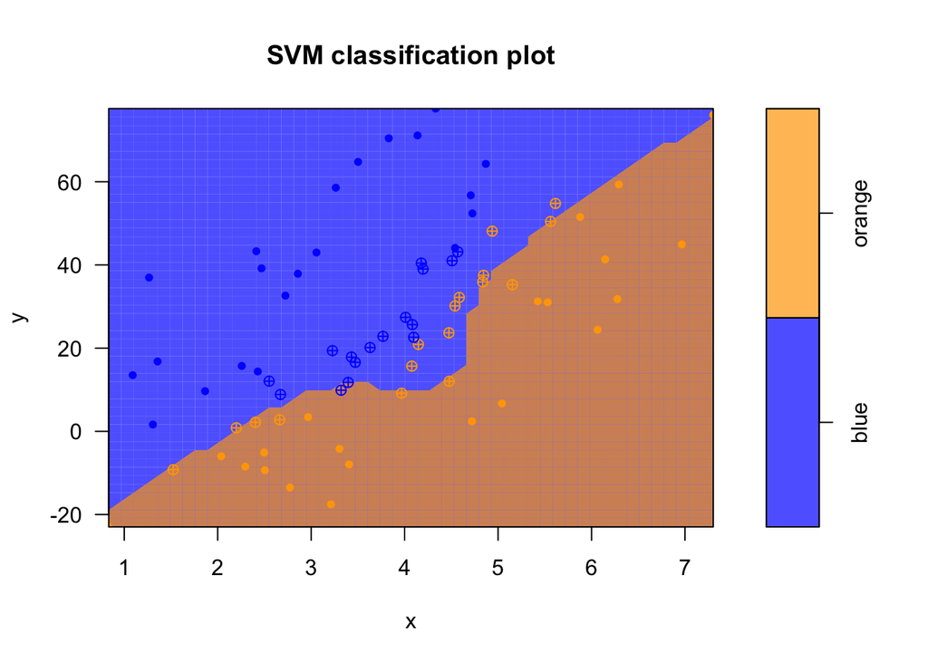

```r
svmfit_poly <- svm(k ~ y + x, data = train, kernel = "polynomial", d = 3,
                   cost = 10)

plot(
  svmfit_poly,
  train,
  symbolPalette = c("blue", "orange"),
  svSymbol = 10,
  dataSymbol = 20,
  color.palette = function(x) c(alpha("blue", 0.7), alpha("orange", 0.7))
)
```

Let’s try optimising the polynomial kernel SVM:

```r
svmfit_poly_tune <- tune(
  svm,
  k ~ y + x,
  data = train,
  kernel = "polynomial",
  ranges = list(
    d = 1:8,
    cost = c(0.001, 0.01, 0.1, 1, 10, 100, 1000)
  )
)

svmfit_poly_tune$best.parameters
```

```
##    d cost
## 51 3 1000
```

Recover best model:

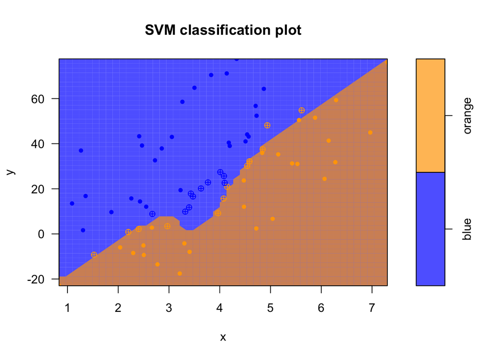

```r
svmfit_poly_opt <- svmfit_poly_tune$best.model
svmfit_poly_opt_pred <- predict(svmfit_poly_opt, test)

svmfit_poly_opt_conf <- confusionMatrix(svmfit_poly_opt_pred, test$k)

plot(
  svmfit_poly_opt,
  train,
  symbolPalette = c("blue", "orange"),
  svSymbol = 10,
  dataSymbol = 20,
  color.palette = function(x) c(alpha("blue", 0.7), alpha("orange", 0.7))
)
```

```r
svmfit_poly_opt_conf
```

```
## Confusion Matrix and Statistics
##
##           Reference
## Prediction blue orange
##     blue     13      6
##     orange    0      6
##
##                Accuracy : 0.76
##                  95% CI : (0.5487, 0.9064)
##     No Information Rate : 0.52
##     P-Value [Acc > NIR] : 0.01243
##
##                   Kappa : 0.5098
##
##  Mcnemar's Test P-Value : 0.04123
##
##             Sensitivity : 1.0000
##             Specificity : 0.5000
##          Pos Pred Value : 0.6842
##          Neg Pred Value : 1.0000
##              Prevalence : 0.5200
##          Detection Rate : 0.5200
##    Detection Prevalence : 0.7600
##       Balanced Accuracy : 0.7500
##
##        'Positive' Class : blue
##
```

It is considerably more accurate SVM with radial basis kernel:

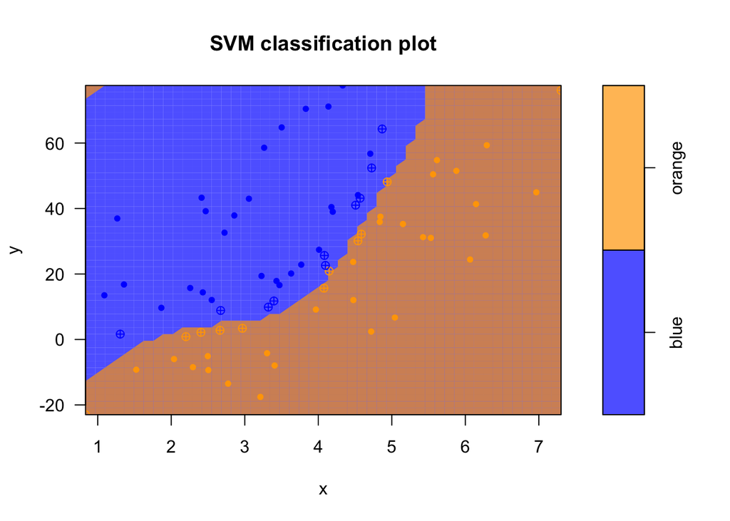

```r
svmfit_radial <- svm(k ~ y + x, data = train, kernel = "radial",
                     gamma = 0.5, cost = 10)

plot(
  svmfit_radial,
  train,
  symbolPalette = c("blue", "orange"),
  svSymbol = 10,
  dataSymbol = 20,
  color.palette = function(x) c(alpha("blue", 0.7), alpha("orange", 0.7))
)
```

```r
svmfit_radial_pred <- predict(svmfit_radial, test)
svmfit_radial_conf <- confusionMatrix(svmfit_radial_pred, test$k)

svmfit_radial_conf
```

```
## Confusion Matrix and Statistics
##
##           Reference
## Prediction blue orange
##     blue     13      3
##     orange    0      9
##
##                Accuracy : 0.88
##                  95% CI : (0.6878, 0.9745)
##     No Information Rate : 0.52
##     P-Value [Acc > NIR] : 0.0001659
##
##                   Kappa : 0.7573
##
##  Mcnemar's Test P-Value : 0.2482131
##
##             Sensitivity : 1.0000
##             Specificity : 0.7500
##          Pos Pred Value : 0.8125
##          Neg Pred Value : 1.0000
##              Prevalence : 0.5200
##          Detection Rate : 0.5200
##    Detection Prevalence : 0.6400
##       Balanced Accuracy : 0.8750
##
##        'Positive' Class : blue
##
```

Tune the model:

```r
svmfit_radial_tune <- tune(
  svm,
  k ~ y + x,
  data = train,
  kernel = "radial",
  ranges = list(
    gamma = 10^seq(-2, 2, length.out = 20),
    cost = 10^seq(-2, 2, length.out = 20)
  )
)

svmfit_radial_tune$best.parameters
```

```
##         gamma    cost
## 348 0.2976351 37.9269
```

The best model:

```r
svmfit_radial_opt <- svmfit_radial_tune$best.model
svmfit_radial_opt_pred <- predict(svmfit_radial_opt, test)
svmfit_radial_opt_conf <- confusionMatrix(svmfit_radial_opt_pred, test$k)
svmfit_radial_opt_conf
```

```
## Confusion Matrix and Statistics
##
##           Reference
## Prediction blue orange
##     blue     13      2
##     orange    0     10
##
##                Accuracy : 0.92
##                  95% CI : (0.7397, 0.9902)
##     No Information Rate : 0.52
##     P-Value [Acc > NIR] : 2.222e-05
##
##                   Kappa : 0.8387
##
##  Mcnemar's Test P-Value : 0.4795
##
##             Sensitivity : 1.0000
##             Specificity : 0.8333
##          Pos Pred Value : 0.8667
##          Neg Pred Value : 1.0000
##              Prevalence : 0.5200
##          Detection Rate : 0.5200
##    Detection Prevalence : 0.6000
##       Balanced Accuracy : 0.9167
##
##        'Positive' Class : blue
##
```

The accuracy is very high.

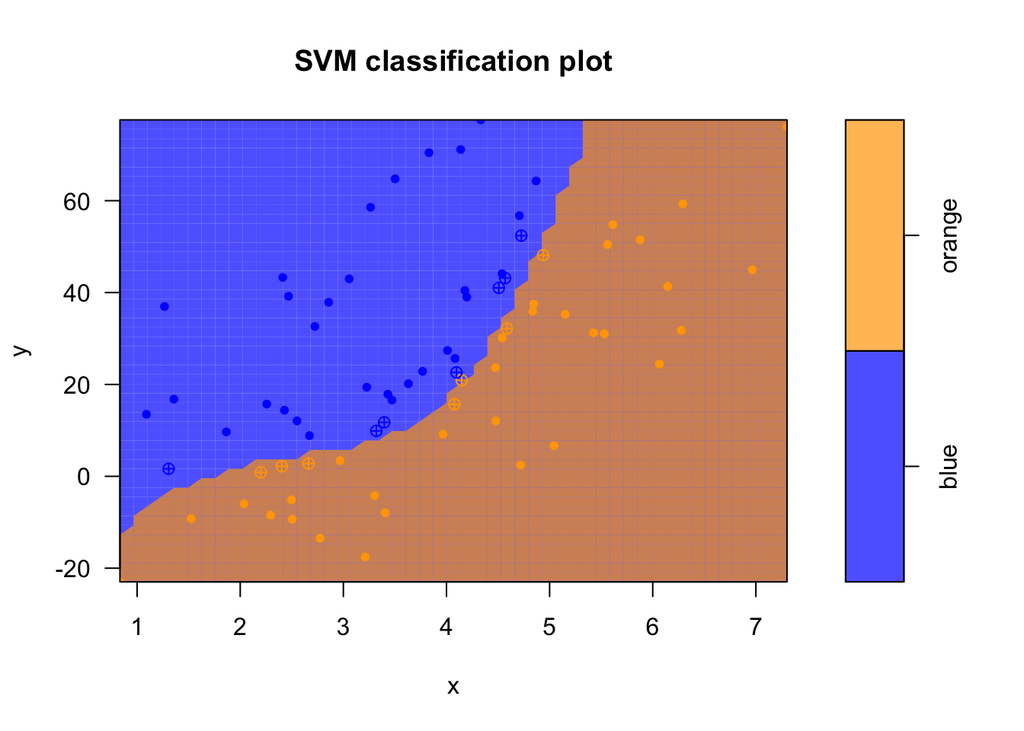

```r
plot(
  svmfit_radial_opt,
  train,
  symbolPalette = c("blue", "orange"),
  svSymbol = 10,
  dataSymbol = 20,
  color.palette = function(x) c(alpha("blue", 0.7), alpha("orange", 0.7))
)
```

Radial basis kernel SVM for the win.